# Inside Context Memory

> This notebook focuses on context memory inside the rooms.

# 1 Overview of the data

The rooms were separated into *Familiar* and *Novel* groups. Participants explored the *Familiar* group at the beginning of the experiment. In the encoding task, they visisted both *Familiar* and *Novel* groups. Their context memory (i.e., in which room they saw the item) was tested in the memory test the next day of the encoding task. **Novelty benefits** on the context memory are examined by comparing the memory performance between the *Familiar* and *Novel* groups.

Participants were also asked to rate how curious they felt about the room. The higher the rating is means they felt more curious about the room. Context memory as a function of curiosity rating was also examined for **curiosity benefits**.

Questionnaires on personal traits regarding curiosity were also administered to participants before the encoding task (i.e., PC and EC). Scores on these questionnaires might be able to predict the context memory or its relationship with curiosity rating.

In the encoding task, there were 6 objects in each room. It is possbile that the context memory for the object to some extent depends on the order in which the object was seen. For example, it may be easier to remember where the first and last objects were seen as compared to those in the middle.

# 2 Individual performance

## 2.1 An overview of individual context memory performance as a function of room.

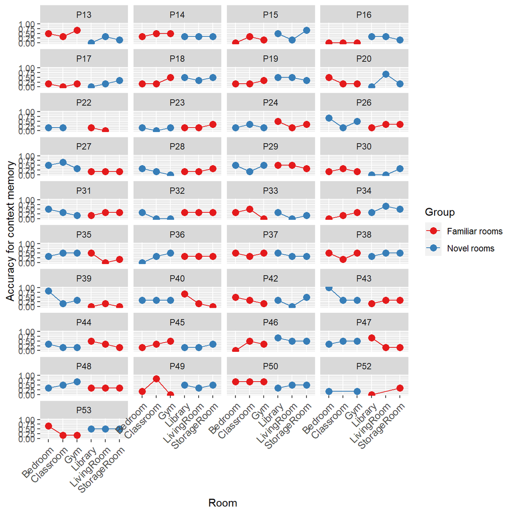

Figure1. Mean accuracy for context memory respectively for each room and each individual participant.

## 2.2 For correctly labelled distractor items

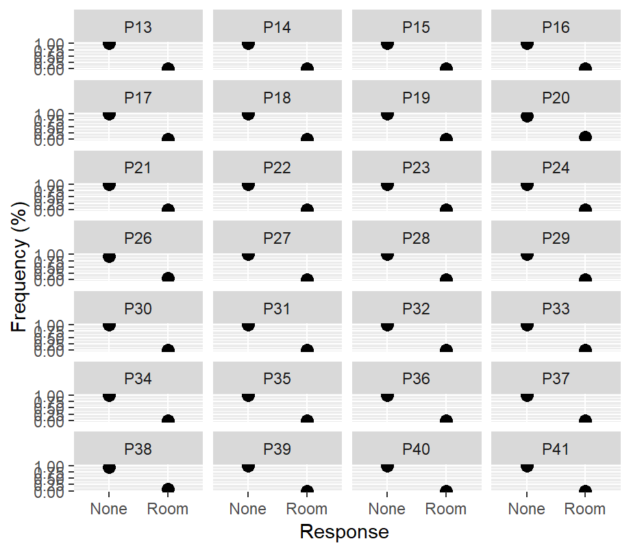

Figure2. Frequency of correctly labelled distractor objects for each individual participant.

## 2.3 For correctly recalled items

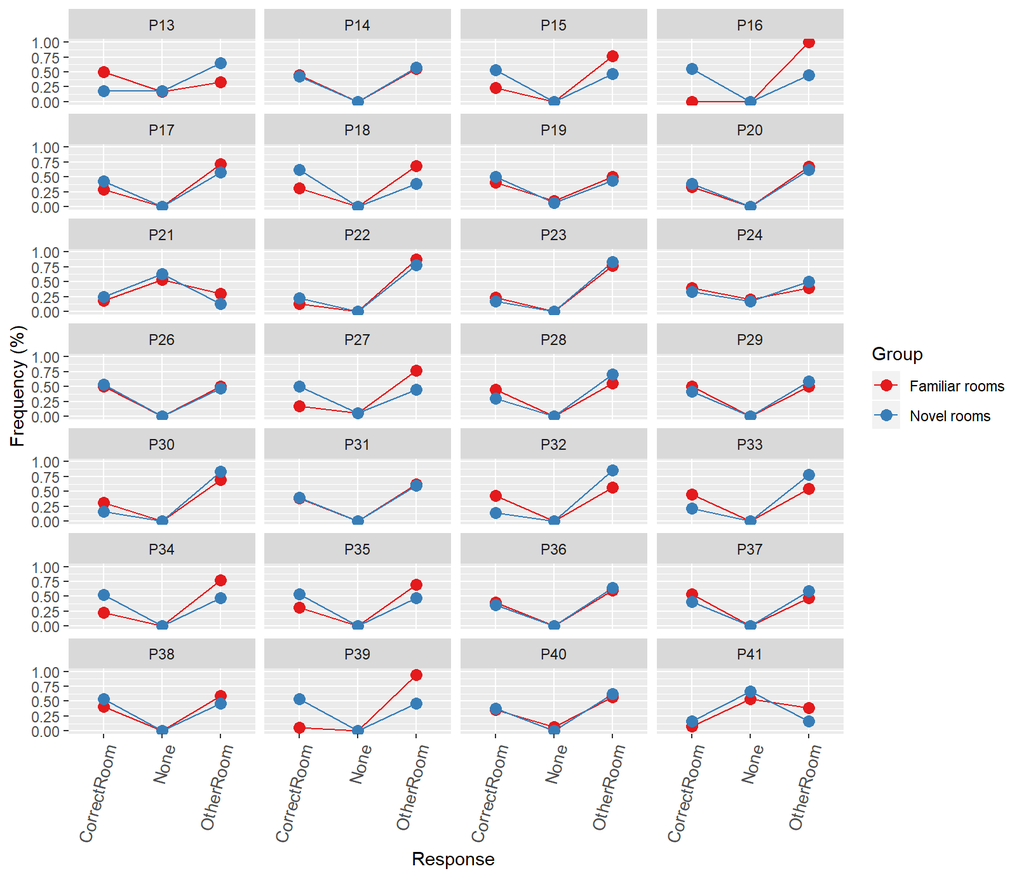

# 3 Novelty Benefits

We hypothesed that the context memory should be better in the *novel* rooms than in the *familiar* rooms.

## 3.1 Compare mean accuracy between *novel* and *familiar* rooms

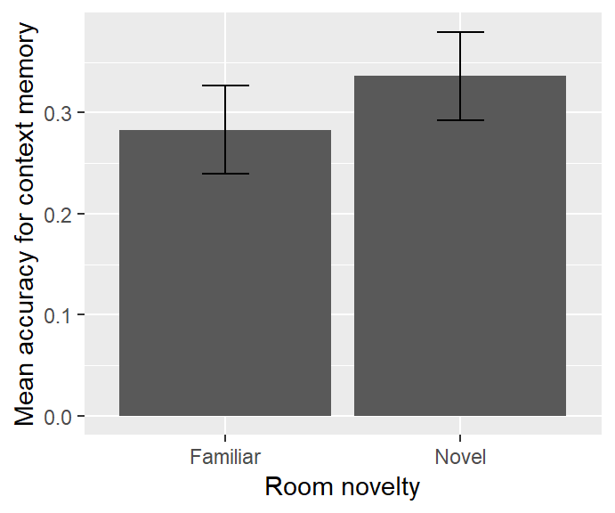

Figure4. Mean accuracy for context memory respectively for Familiar and Novel rooms.

As we predicted, the mean accuracy of context memory is higher in the *novel* rooms than in the *familiar* rooms.

```
##
##  Paired t-test
##
## data:  MeanContextAccuracy by Group
## t = -1.82, df = 36, p-value = 0.07708
## alternative hypothesis: true difference in means is not equal to 0
## 95 percent confidence interval:
##  -0.112701783  0.006095176
## sample estimates:
## mean of the differences
##              -0.0533033
```

## 3.2 Context memory as a function of item order

### 3.2.1 Visualise the data

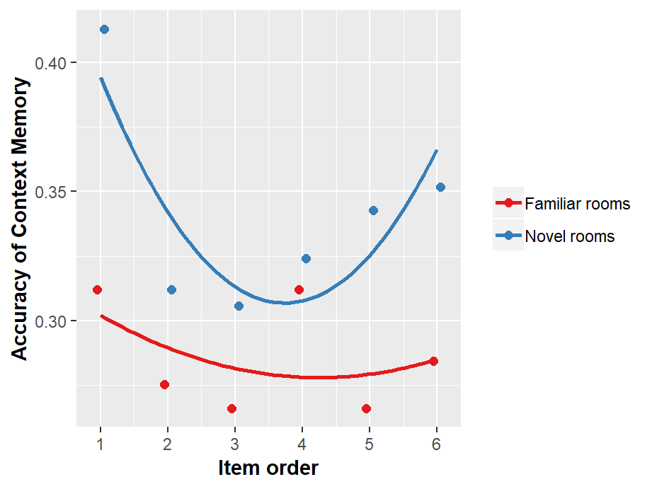

Figure 5. Mean accuracy of context memory for items at each order (i.e., 1st, 2nd, 3rd, etc), respectively for familiar and novel rooms.

### 3.2.2 Testing novelty effects by fitting mixed models

Build models with context memory accuracy as $y$ and examine effects of item order and novelty by comparing the models.

- `baseline.context` is the model with only an intercept.
- `order.model.linear.1` is the model with $\small ItemOrder$ included, showing the effects of item order.
- `order.model.linear.2` is the model allowing the slope (i.e., relationship between context memory and item order) varying across participants.
- `order.model.quad.1` and `order.model.quad.2` repectively included $\small ItemOrder^2$ and related random effects.
- `novelty.model.1` is the model with $\small Group$ (i.e., *familiar* and *novel* rooms) included, examining the effects of novelty of the rooms on the intercept (i.e., mean context memory accuracy at the 1st order or overall if no difference in slope).
- `novelty.model.2` is the model with interaction between $\small Group$ and $\small ItemOrder$ included, examining the effects of novelty on how context memory accuracy changes as a function of item order.
- `novelty.model.3` included interaction between $\small Group$ and $\small ItemOrder^2$ for inestigating whether the pattern changes between *familiar* and *novel* groups.

```
##                      Model df      AIC      BIC    logLik   Test  L.Ratio
## baseline.context         1  3 1700.555 1716.075 -847.2777
## order.model.linear.1     2  4 1702.180 1722.873 -847.0902 1 vs 2 0.375119
## order.model.linear.2     3  6 1706.188 1737.227 -847.0940 2 vs 3 0.007617
## order.model.quad.1       4  7 1706.327 1742.540 -846.1637 3 vs 4 1.860612
## order.model.quad.2       5 10 1712.321 1764.052 -846.1603 4 vs 5 0.006869
## novelty.model.1          6 14 1713.669 1786.094 -842.8346 5 vs 6 6.651272
## novelty.model.2          7 15 1715.645 1793.243 -842.8226 6 vs 7 0.023954
## novelty.model.3          8 16 1716.789 1799.560 -842.3942 7 vs 8 0.856795
##                      p-value
## baseline.context
## order.model.linear.1  0.5402
## order.model.linear.2  0.9962
## order.model.quad.1    0.1726
## order.model.quad.2    0.9998
## novelty.model.1       0.1555
## novelty.model.2       0.8770
## novelty.model.3       0.3546
```

Now including none of the predictors would improve the model fit.

#### 3.2.2.1 Parameter estimation for the complete model

```
## Linear mixed-effects model fit by maximum likelihood
##  Data: Encoding.Recall.Old
##        AIC     BIC    logLik
##   1716.788 1799.56 -842.3942
##
## Random effects:
##  Formula: ~1 + ItemOrder + I(ItemOrder^2) | SubjectNo
##  Structure: General positive-definite, Log-Cholesky parametrization
##                StdDev      Corr
## (Intercept)    0.009167207 (Intr) ItmOrd
## ItemOrder      0.003263667 -0.012
## I(ItemOrder^2) 0.001595963 -0.355 -0.452
##
##  Formula: ~1 + Group | SubjectNo %in% SubjectNo
##  Structure: General positive-definite, Log-Cholesky parametrization
##             StdDev     Corr
## (Intercept) 0.05651760 (Intr)
## GroupNovel  0.08806136 -0.477
## Residual    0.45676727
##
## Fixed effects: ContextAccuracy ~ ItemOrder + I(ItemOrder^2) + Group + ItemOrder:Group +      I(ItemOrder^2):Group
##                                Value  Std.Error   DF   t-value p-value
## (Intercept)                0.3187117 0.07901184 1262  4.033720  0.0001
## ItemOrder                 -0.0194652 0.05132286 1262 -0.379270  0.7046
## I(ItemOrder^2)             0.0022926 0.00718171 1262  0.319233  0.7496
## GroupNovel                 0.1503340 0.11195501 1262  1.342807  0.1796
## ItemOrder:GroupNovel      -0.0679676 0.07267413 1262 -0.935237  0.3498
## I(ItemOrder^2):GroupNovel  0.0093837 0.01016592 1262  0.923056  0.3562
##  Correlation:
##                           (Intr) ItmOrd I(ItO^2) GrpNvl ItO:GN
## ItemOrder                 -0.925
## I(ItemOrder^2)             0.847 -0.978
## GroupNovel                -0.703  0.653 -0.598
## ItemOrder:GroupNovel       0.653 -0.706  0.691   -0.924
## I(ItemOrder^2):GroupNovel -0.599  0.691 -0.705    0.847 -0.979
##
## Standardized Within-Group Residuals:
##        Min         Q1        Med         Q3        Max
## -1.0250239 -0.6790344 -0.5927901  1.3503459  1.6919768
##
## Number of Observations: 1304
## Number of Groups:
##                  SubjectNo SubjectNo.1 %in% SubjectNo
##                         37                         37
```

```r
#### Parameter estimation for the optimal model
summary(order.model.quad.1, correlation = FALSE)
```

[output not shown]

### 3.2.3 Collapse the order

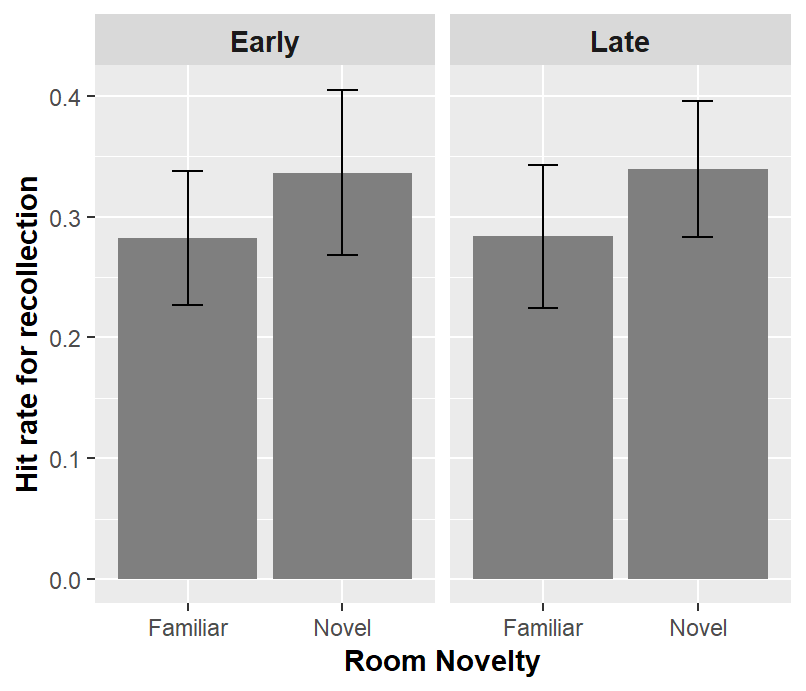

#### 3.2.3.1 Stats on it

```
## Linear mixed-effects model fit by maximum likelihood
##  Data: Encoding.Recall.Old.Collapsed.Grp
##        AIC       BIC   logLik
##   -70.5677 -37.59836 46.28385
##
## Random effects:
##  Formula: ~Group + ItemOrderType | SubjectNo
##  Structure: General positive-definite, Log-Cholesky parametrization
##                   StdDev     Corr
## (Intercept)       0.04012820 (Intr) GrpNvl
## GroupNovel        0.07351683 -0.108
## ItemOrderTypeLate 0.04597376  0.547 -0.841
## Residual          0.16448797
##
## Fixed effects: ContextAccuracy ~ Group * ItemOrderType
##                                   Value  Std.Error  DF   t-value p-value
## (Intercept)                  0.28228228 0.02821867 108 10.003386  0.0000
## GroupNovel                   0.05405405 0.04066028 108  1.329407  0.1865
## ItemOrderTypeLate            0.00150150 0.03952010 108  0.037993  0.9698
## GroupNovel:ItemOrderTypeLate 0.00150150 0.05482932 108  0.027385  0.9782
##  Correlation:
##                              (Intr) GrpNvl ItmOTL
## GroupNovel                   -0.663
## ItemOrderTypeLate            -0.649  0.419
## GroupNovel:ItemOrderTypeLate  0.486 -0.674 -0.694
##
## Standardized Within-Group Residuals:
##        Min         Q1        Med         Q3        Max
## -2.0401083 -0.6209622 -0.1918995  0.5746938  2.3043790
##
## Number of Observations: 148
## Number of Groups: 37
```

# 4 Curiosity Benefits

We predicted that the accuracy of context memory should increase as the curiosity rating increases.

## 4.1 Mean accuracy of context memory as a function of curiosity rating

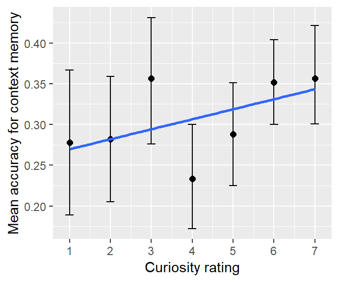

Figure 7. Mean accuracy for context memory as a function of curiosity rating.

As we predicted, the accuracy of context memory *increases* as the curiosity rating increases.

### 4.1.1 Testing the relationship between mean accuracy of context memory and curiosity rating

Build models with context memory accuracy as $y$ and examine effects of curiosity rating by including it into the model and then comparing the model fits.

- `baseline.rating` is the model with only an intercept, showing no change in context memory as a function of curiosity rating.
- `rating.intercept` is the model with $\small CuriosityRating$ included, showing the effects of curiosity rating.
- `rating.slope` is the model allowing the slope (i.e., relationship between context memory and curiosity rating) varying across participants.

```
##                  Model df       AIC       BIC   logLik   Test  L.Ratio
## baseline.rating      1  3 -88.86791 -78.71443 47.43396
## rating.intercept     2  4 -90.28971 -76.75173 49.14485 1 vs 2 3.421795
## rating.slope         3  6 -87.63578 -67.32881 49.81789 2 vs 3 1.346072
##                  p-value
## baseline.rating
## rating.intercept  0.0643
## rating.slope      0.5102
```

#### 4.1.1.1 Parameter estimates in the complete model

```r
summary(rating.slope)
```

```
## Linear mixed-effects model fit by maximum likelihood
##  Data: InsideObjectsMemory
##         AIC       BIC   logLik
##   -87.63578 -67.32881 49.81789
##
## Random effects:
##  Formula: ~1 + CuriosityRating | SubjectNo
##  Structure: General positive-definite, Log-Cholesky parametrization
##                 StdDev    Corr
## (Intercept)     0.1366725 (Intr)
## CuriosityRating 0.0242886 -0.896
## Residual        0.1795050
##
## Fixed effects: ContextAccuracy ~ CuriosityRating
##                     Value  Std.Error  DF  t-value p-value
## (Intercept)     0.2465197 0.04055912 180 6.078034  0.0000
## CuriosityRating 0.0144063 0.00798456 180 1.804269  0.0729
##  Correlation:
##                 (Intr)
## CuriosityRating -0.918
##
## Standardized Within-Group Residuals:
##         Min          Q1         Med          Q3         Max
## -1.92856808 -0.73442639 -0.02630047  0.72731088  3.24631230
##
## Number of Observations: 218
## Number of Groups: 37
```

The estimated value for the parameter $CuriosityRating$ is positive, as what we observed on Figure 7, but not significant. Will wait for more participants to see how this relationship changes.

#### 4.1.1.2 Plot the model

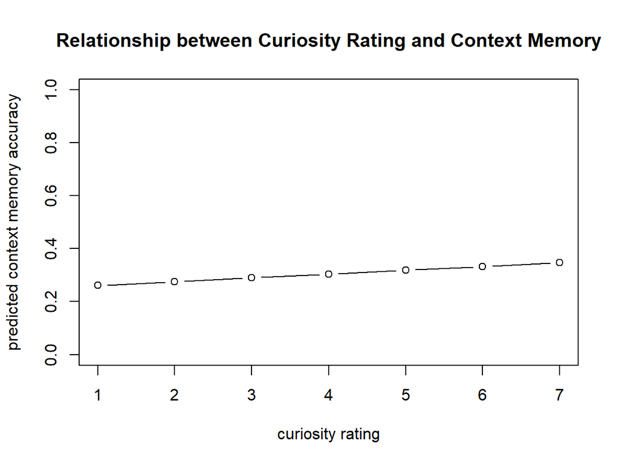

## 4.2 Does the relationship with curiosity rating depend on item order?

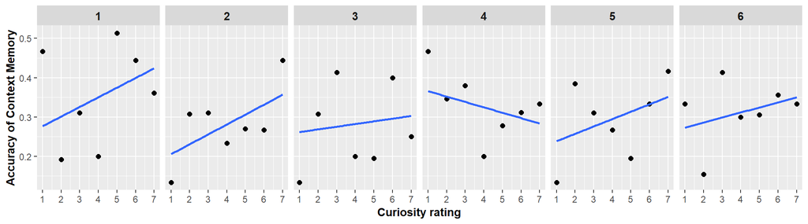

Figure 7. Mean accuracy across participants for context memory as a function of curiosity rating for each order at which the item was seen (I.e., 1st, 2nd, 3rd, etc.).

For almost all the orders, there is a positive trend.

### 4.2.1 Testing the effect of item order

Build models with context memory accuracy as $y$ and examine effects of curioity rating and item order by comparing the models.

- `item.model.linear.1` is the model with $\small ItemOrder$ included (in addition to $\small CuriosityRating$), showing the effects of item order.
- `item.model.linear.2` is the model allowing the slope (i.e., relationship between context memory and item order) varying across participants.
- `item.model.linear.3` is the model with the interaction between $\small ItemOrders$ and $\small CuriosityRating$ included.
- `item.model.quad.1` and `item.model.quad.2` repectively included $\small ItemOrder^2$ and related random effects.
- `item.model.quad.3` included interaction between $\small ItemOrder^2$ and $\small CuriosityRating$ for inestigating whether the pattern changes as a function of *curiosity rating*.

```r
rating.intercept <- update(baseline.context, .~. + CuriosityRating)
rating.slope     <- update(rating.intercept, random = ~ 1 + CuriosityRating | SubjectNo)

item.model.linear.1     <- update(rating.slope, .~. + ItemOrder)
item.model.linear.2     <- update(item.model.linear.1, random = list(~1+CuriosityRating|SubjectNo, ~1+ItemOrder|SubjectNo))
item.model.linear.3     <- update(item.model.linear.2, .~. + ItemOrder : CuriosityRating)

item.model.quad.1       <- update(item.model.linear.3, .~. + I(ItemOrder^2))
# item.model.quad.2       <- update(item.model.quad.1,   random = list(~1+CuriosityRating|SubjectNo, ~1+ItemOrder+I(ItemOrder^2)|SubjectNo)) - excluding this model because singularity issue (perhaps the model was getting too complex to be calculated)
item.model.quad.3       <- update(item.model.quad.1,   .~. + I(ItemOrder^2) : CuriosityRating)

anova(rating.intercept, rating.slope, item.model.linear.1, item.model.linear.2, item.model.linear.3, item.model.quad.1, item.model.quad.3)
```

```
##                     Model df      AIC      BIC    logLik   Test   L.Ratio
## rating.intercept        1  4 1699.133 1719.826 -845.5665
## rating.slope            2  6 1702.268 1733.307 -845.1338 1 vs 2 0.8653992
## item.model.linear.1     3  7 1703.890 1740.102 -844.9450 2 vs 3 0.3776150
## item.model.linear.2     4 10 1709.857 1761.589 -844.9285 3 vs 4 0.0329865
## item.model.linear.3     5 11 1711.361 1768.266 -844.6803 4 vs 5 0.4964944
## item.model.quad.1       6 12 1711.484 1773.562 -843.7418 5 vs 6 1.8769268
## item.model.quad.3       7 13 1712.240 1779.491 -843.1199 6 vs 7 1.2437084
##                     p-value
## rating.intercept
## rating.slope         0.6488
## item.model.linear.1  0.5389
## item.model.linear.2  0.9984
## item.model.linear.3  0.4810
## item.model.quad.1    0.1707
## item.model.quad.3    0.2648
```

#### 4.2.1.1 Parameter estimation for the complete model

```r
summary(item.model.quad.3)
```

```
## Linear mixed-effects model fit by maximum likelihood
##  Data: Encoding.Recall.Old
##       AIC      BIC    logLik
##   1712.24 1779.491 -843.1199
##
## Random effects:
##  Formula: ~1 + CuriosityRating | SubjectNo
##  Structure: General positive-definite, Log-Cholesky parametrization
##                 StdDev     Corr
## (Intercept)     0.11878107 (Intr)
## CuriosityRating 0.02062987 -0.909
##
##  Formula: ~1 + ItemOrder | SubjectNo %in% SubjectNo
##  Structure: General positive-definite, Log-Cholesky parametrization
##             StdDev      Corr
## (Intercept) 0.019385039 (Intr)
## ItemOrder   0.004482567 -0.306
## Residual    0.457762415
##
## Fixed effects: ContextAccuracy ~ CuriosityRating + ItemOrder + I(ItemOrder^2) +      CuriosityRating:ItemOrder + CuriosityRating:I(ItemOrder^2)
##                                      Value  Std.Error   DF    t-value
## (Intercept)                     0.15778184 0.14717333 1262  1.0720817
## CuriosityRating                 0.05236175 0.03013872 1262  1.7373578
## ItemOrder                       0.05512449 0.09519681 1262  0.5790582
## I(ItemOrder^2)                 -0.00671913 0.01331223 1262 -0.5047335
## CuriosityRating:ItemOrder      -0.02411094 0.01955091 1262 -1.2332388
## CuriosityRating:I(ItemOrder^2)  0.00304291 0.00273409 1262  1.1129508
##                                p-value
## (Intercept)                     0.2839
## CuriosityRating                 0.0826
## ItemOrder                       0.5627
## I(ItemOrder^2)                  0.6138
## CuriosityRating:ItemOrder       0.2177
## CuriosityRating:I(ItemOrder^2)  0.2659
##  Correlation:
##                                (Intr) CrstyR ItmOrd I(IO^2 CrR:IO
## CuriosityRating                -0.924
## ItemOrder                      -0.921  0.853
## I(ItemOrder^2)                  0.844 -0.782 -0.979
## CuriosityRating:ItemOrder       0.851 -0.924 -0.924  0.904
## CuriosityRating:I(ItemOrder^2) -0.780  0.847  0.904 -0.924 -0.979
##
## Standardized Within-Group Residuals:
##        Min         Q1        Med         Q3        Max
## -1.0492355 -0.6958157 -0.5984766  1.3759006  1.7050621
##
## Number of Observations: 1304
## Number of Groups:
##                  SubjectNo SubjectNo.1 %in% SubjectNo
##                         37                         37
```

Maybe because of being lack of power (too many parameters and too few participants), no parameter has a significant estimated value.

```r
#### Parameter estimation for the optimal model
summary(item.model.quad.1)
```

[output not shown]

### 4.2.2 Collapse the order and curiosity rating

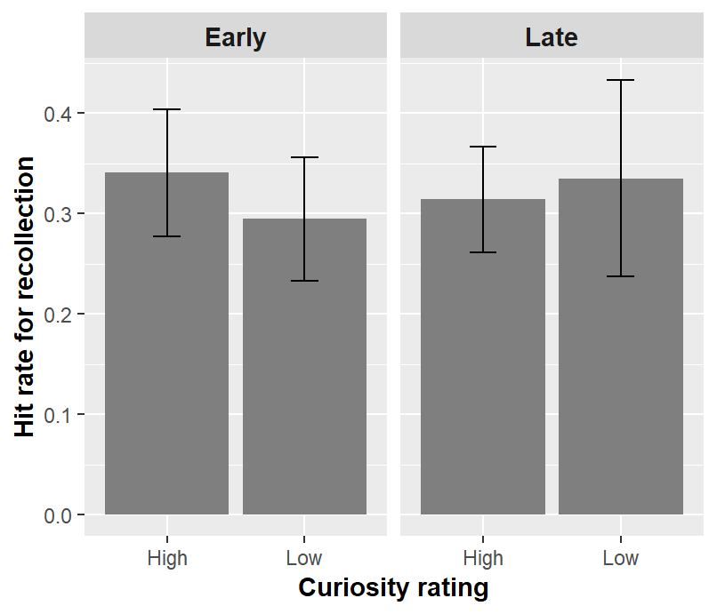

Figure 7. Mean hit rate as a function of item order (Early vs. Late) and curiosity (Low vs. High).

#### 4.2.2.1 Stats on it

```
## Linear mixed-effects model fit by maximum likelihood
##  Data: Encoding.Recall.Old.Collapsed
##        AIC       BIC  logLik
##   -44.4452 -12.08713 33.2226
##
## Random effects:
##  Formula: ~CuriosityRatingType + ItemOrderType | SubjectNo
##  Structure: General positive-definite, Log-Cholesky parametrization
##                        StdDev     Corr
## (Intercept)            0.09616170 (Intr) CrsRTL
## CuriosityRatingTypeLow 0.15338983 -0.763
## ItemOrderTypeLate      0.09028433 -0.713  0.977
## Residual               0.16084745
##
## Fixed effects: ContextAccuracy ~ CuriosityRatingType * ItemOrderType
##                                               Value  Std.Error  DF
## (Intercept)                               0.3404996 0.03125825 100
## CuriosityRatingTypeLow                   -0.0462529 0.04703573 100
## ItemOrderTypeLate                        -0.0263855 0.04082152 100
## CuriosityRatingTypeLow:ItemOrderTypeLate  0.0681270 0.05546932 100
##                                            t-value p-value
## (Intercept)                              10.893113  0.0000
## CuriosityRatingTypeLow                   -0.983357  0.3278
## ItemOrderTypeLate                        -0.646362  0.5195
## CuriosityRatingTypeLow:ItemOrderTypeLate  1.228192  0.2223
##  Correlation:
##                                          (Intr) CrsRTL ItmOTL
## CuriosityRatingTypeLow                   -0.703
## ItemOrderTypeLate                        -0.699  0.571
## CuriosityRatingTypeLow:ItemOrderTypeLate  0.415 -0.577 -0.636
##
## Standardized Within-Group Residuals:
##         Min          Q1         Med          Q3         Max
## -1.90316124 -0.55107662 -0.04098518  0.60307842  2.20413380
##
## Number of Observations: 140
## Number of Groups: 37
```

# 5 Curiosity and novelty

## 5.1 Testing the effects of curiosity rating and novelty together

Build models with context memory accuracy as $y$ and examine effects of curiosity rating and novelty together by including them into the model separately and then comparing the model fits.

```
##                   Model df       AIC       BIC   logLik   Test  L.Ratio
## baseline.rating       1  3 -88.86791 -78.71443 47.43396
## rating.intercept      2  4 -90.28971 -76.75173 49.14485 1 vs 2 3.421795
## rating.slope          3  6 -87.63578 -67.32881 49.81789 2 vs 3 1.346072
## novelty.model.1       4  7 -86.95684 -63.26537 50.47842 3 vs 4 1.321059
## novelty.model.2       5 10 -83.88892 -50.04397 51.94446 4 vs 5 2.932080
## interaction.model     6 11 -83.96538 -46.73594 52.98269 5 vs 6 2.076465
##                   p-value
## baseline.rating
## rating.intercept   0.0643
## rating.slope       0.5102
## novelty.model.1    0.2504
## novelty.model.2    0.4022
## interaction.model  0.1496
```

```
## Linear mixed-effects model fit by maximum likelihood
##  Data: InsideObjectsMemory
##         AIC       BIC   logLik
##   -83.88892 -50.04397 51.94446
##
## Random effects:
##  Formula: ~1 + CuriosityRating | SubjectNo
##  Structure: General positive-definite, Log-Cholesky parametrization
##                 StdDev     Corr
## (Intercept)     0.13158049 (Intr)
## CuriosityRating 0.01823493 -0.981
##
##  Formula: ~1 + Group | SubjectNo %in% SubjectNo
##  Structure: General positive-definite, Log-Cholesky parametrization
##             StdDev     Corr
## (Intercept) 0.00886170 (Intr)
## GroupNovel  0.09205399 -0.975
## Residual    0.17401734
##
## Fixed effects: ContextAccuracy ~ CuriosityRating + Group
##                      Value  Std.Error  DF  t-value p-value
## (Intercept)     0.27234163 0.04359353 179 6.247295  0.0000
## CuriosityRating 0.00331408 0.01105274 179 0.299842  0.7646
## GroupNovel      0.04830139 0.04070601 179 1.186591  0.2370
##  Correlation:
##                 (Intr) CrstyR
## CuriosityRating -0.877
## GroupNovel       0.379 -0.689
##
## Standardized Within-Group Residuals:
##         Min          Q1         Med          Q3         Max
## -1.80919678 -0.63886355 -0.00364322  0.62804806  3.24367903
##
## Number of Observations: 218
## Number of Groups:
##                  SubjectNo SubjectNo.1 %in% SubjectNo
##                         37                         37
```

## 5.2 What about the other way around

```
##                  Model df      AIC      BIC    logLik   Test  L.Ratio
## baseline.context     1  3 1700.555 1716.075 -847.2777
## novelty.model.1      2  4 1697.840 1718.532 -844.9198 1 vs 2 4.715849
## novelty.model.2      3  6 1700.039 1731.079 -844.0197 2 vs 3 1.800249
## rating.model.1       4  7 1701.970 1738.183 -843.9852 3 vs 4 0.068911
## rating.model.2       5 10 1707.641 1759.373 -843.8205 4 vs 5 0.329475
##                  p-value
## baseline.context
## novelty.model.1   0.0299
## novelty.model.2   0.4065
## rating.model.1    0.7929
## rating.model.2    0.9544
```

### 5.2.1 Check the model

```
## Linear mixed-effects model fit by maximum likelihood
##  Data: Encoding.Recall.Old
##        AIC      BIC    logLik
##   1707.641 1759.373 -843.8205
##
## Random effects:
##  Formula: ~1 + CuriosityRating | SubjectNo
##  Structure: General positive-definite, Log-Cholesky parametrization
##                 StdDev     Corr
## (Intercept)     0.11076114 (Intr)
## CuriosityRating 0.01771489 -0.897
##
##  Formula: ~1 + Group | SubjectNo %in% SubjectNo
##  Structure: General positive-definite, Log-Cholesky parametrization
##             StdDev     Corr
## (Intercept) 0.00680037 (Intr)
## GroupNovel  0.06704096 -0.549
## Residual    0.45697755
##
## Fixed effects: ContextAccuracy ~ Group + CuriosityRating
##                      Value  Std.Error   DF  t-value p-value
## (Intercept)     0.27439363 0.04328802 1265 6.338789  0.0000
## GroupNovel      0.04956946 0.04156284 1265 1.192639  0.2332
## CuriosityRating 0.00294139 0.01149153 1265 0.255961  0.7980
##  Correlation:
##                 (Intr) GrpNvl
## GroupNovel       0.411
## CuriosityRating -0.874 -0.718
##
## Standardized Within-Group Residuals:
##        Min         Q1        Med         Q3        Max
## -0.9764442 -0.6682478 -0.5941345  1.3537316  1.7010011
##
## Number of Observations: 1304
## Number of Groups:
##                  SubjectNo SubjectNo.1 %in% SubjectNo
##                         37                         37
```